# R: data science für Archäolog*innen

27. November 2019

## R: *data science* für Archäolog*innen

> Data Science ist ein interdisziplinäres Wissenschaftsfeld, welches wissenschaftlich fundierte Methoden, Prozesse, Algorithmen und Systeme zur Extraktion von Erkenntnissen, Mustern und Schlüssen sowohl aus strukturierten als auch unstrukturierten Daten ermöglicht. — https://de.wikipedia.org/wiki/Data_Science

## R: *data science* für Archäolog*innen

[figure not shown]

## R - Was überhaupt?

- R ist eine Programmiersprache (Interpretersprache)
- Zugeschnitten auf die statistische Auswertung von Daten vieler Art
- Tool zur Erstellung von Grafiken (Diagramme, Schaubilder, Karten - nahezu alles ist möglich)

Was ist so toll daran?

- Alle Betriebssysteme!
- OpenSource!
- Reproduzierbar!
- Flexibel!

## Archäologische Daten in Tabellenform

| Vase.Number | Fabric | Technique | Provenance | DAT_min | DAT_max | Shape | Provenance_full | Provenance_city |
| --- | --- | --- | --- | --- | --- | --- | --- | --- |
| 18684 | ATHENIAN | BLACK-FIGURE | CORINTH | -400 | -300 | AMPHORA | CORINTH |  |
| 202162 | ATHENIAN | RED-FIGURE |  | -500 | -450 | AMPHORA |  |  |
| 250136 | ATHENIAN | RED-FIGURE |  | -450 | -400 | CUP |  |  |
| 44644 | ATHENIAN | BLACK-FIGURE |  | -500 | -450 | LEKYTHOS |  |  |
| 203489 | ATHENIAN | RED-FIGURE |  | -500 | -450 | CUP |  |  |
| 287 | ATHENIAN | RED-FIGURE |  | -525 | -475 | CUP |  |  |
| 28547 | ATHENIAN | BLACK-FIGURE |  | -575 | -525 | CUP |  |  |
| 331051 | ATHENIAN | BLACK-FIGURE |  | -550 | -500 | CUP |  |  |
| 330768 | ATHENIAN | BLACK-FIGURE |  | -525 | -475 | OINOCHOE |  |  |

*Beispiel 1*: Tabelle mit (bereinigten) Daten aus der Beazley Archive Pottery Database (https://www.beazley.ox.ac.uk/pottery/default.htm)

## Was tun damit?

```r
str(beazley)
```

```
## 'data.frame':    62670 obs. of  9 variables:
##  $ Vase.Number    : int  1 2 5 6 10 12 16 18 19 20 ...
##  $ Fabric         : Factor w/ 23 levels "ATHENIAN","ATHENIAN (?)",..: 1 1 1 1 1 1 1 1 1 1 ...
##  $ Technique      : Factor w/ 2 levels "BLACK-FIGURE",..: 1 1 1 1 1 1 1 1 1 1 ...
##  $ Provenance     : Factor w/ 142 levels "AEGINA","ALBANIA",..: 44 34 NA NA NA 34 NA NA NA NA ...
##  $ DAT_min        : int  -550 -550 -525 -525 -550 -300 -525 -525 -525 -525 ...
##  $ DAT_max        : int  -500 -500 -475 -475 -500 -200 -475 -475 -475 -475 ...
##  $ Shape          : Factor w/ 74 levels "ALABASTRON","AMPHORA",..: 2 39 2 2 2 2 2 2 2 2 ...
##  $ Provenance_full: Factor w/ 1273 levels "","AEGINA","AEGINA (?)",..: 570 22 1 1 1 22 1 1 1 1 ...
##  $ Provenance_city: Factor w/ 643 levels "","(REP.)","ABAI",..: 209 54 NA NA NA 54 NA NA NA NA ...
```

## Zählen!

```r
table(beazley$Technique)
```

```
##
## BLACK-FIGURE   RED-FIGURE
##        29003        33667
```

```r
head(table(beazley$Shape))
```

```
##
##  ALABASTRON     AMPHORA AMPHORISKOS   ARYBALLOS       ASKOS  ASTRAGALOS
##         467        7216           3          51         321           5
```

## Diagramme!

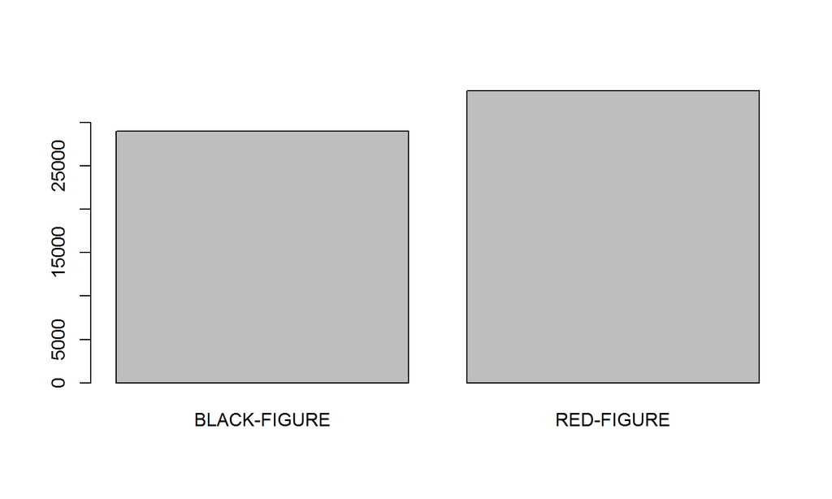

```r
barplot(table(beazley$Technique))
```

## Schönere Diagramme!

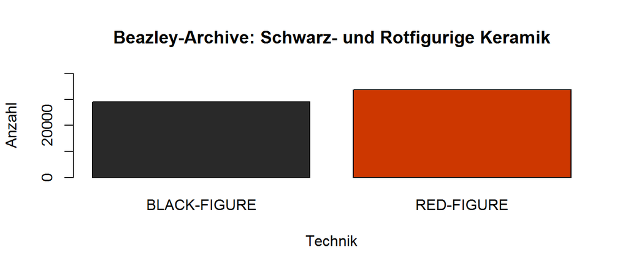

```r
barplot(table(beazley$Technique),
        main = "Beazley-Archive: Schwarz- und Rotfigurige Keramik",
        ylab = "Anzahl", xlab = "Technik", ylim = c(0,40000),
        col = c("gray16", "orangered3"))
```

## Andere Diagramme!

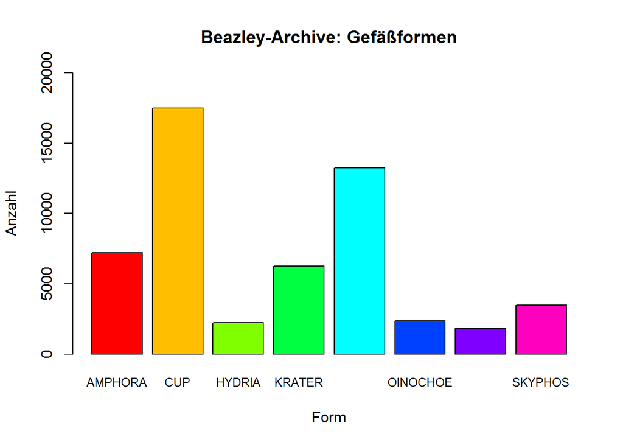

## Sortierte Diagramme!

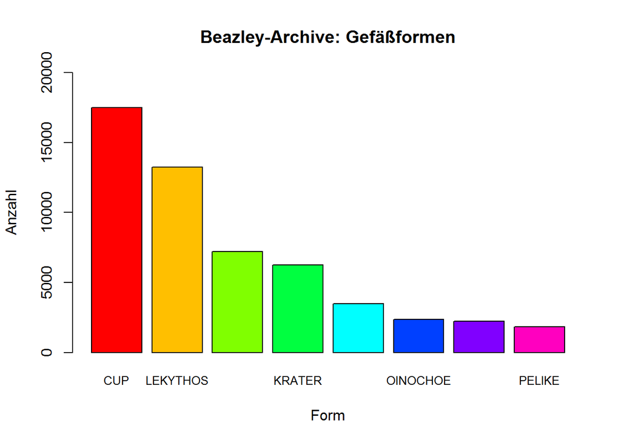

## Kompliziertere sortierte Diagramme!

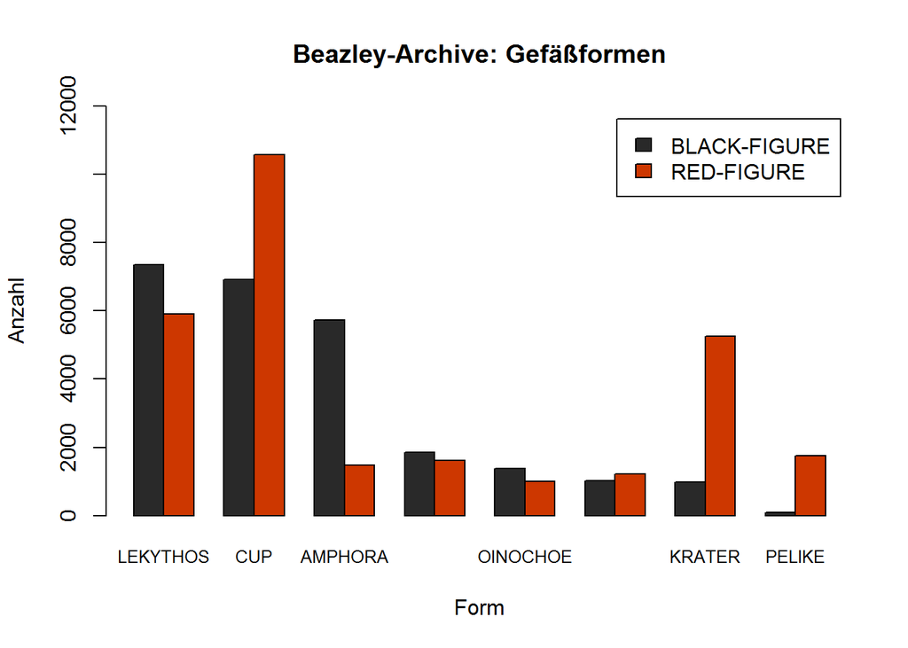

## Kurvendiagramme!

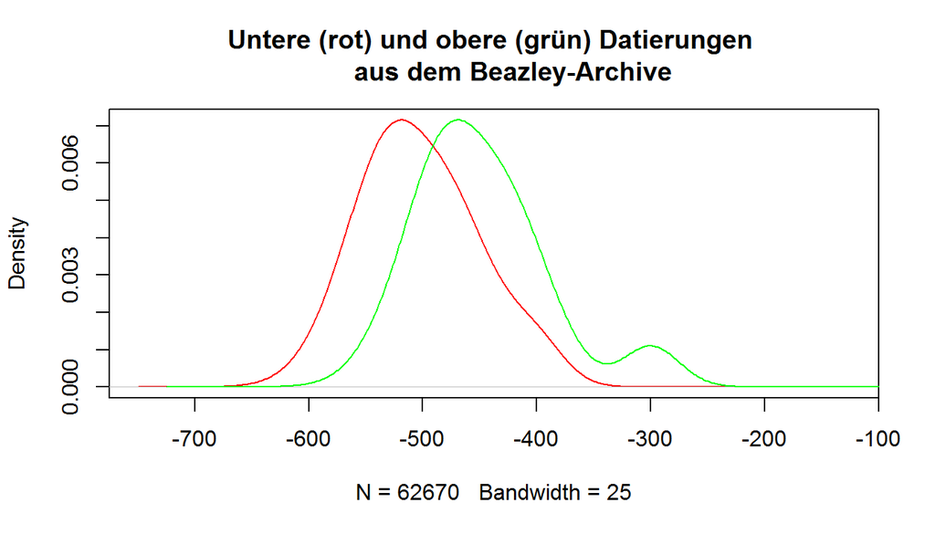

```r
plot(density(beazley$DAT_min, bw = 25), col = "red",
     main = "Untere (rot) und obere (grün) Datierungen
     aus dem Beazley-Archive")
lines(density(beazley$DAT_max, bw = 25), col = "green")
```

## Histogramme!

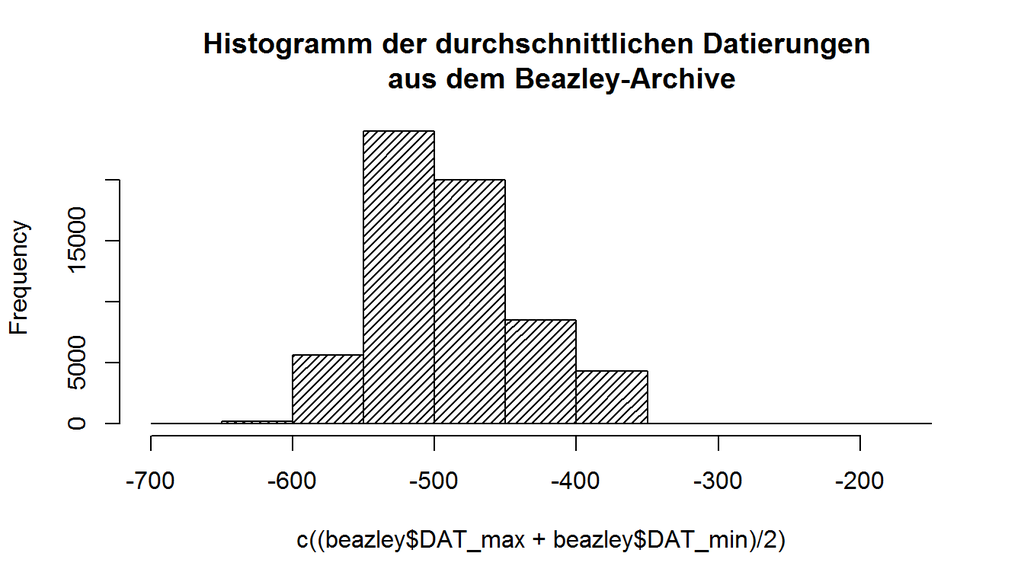

```r
hist(c((beazley$DAT_max + beazley$DAT_min) / 2),
     breaks = 15, density = 25,
     main = "Histogramm der durchschnittlichen Datierungen
     aus dem Beazley-Archive")
```

## Voraussetzungen

- Benötigte Software:
  - Tabellenkalkulationsprogramm (Excel, LibreOffice Calc)
  - R
  - RStudio
- Daten!
- Grundverständnis für die Arten von verfügbaren Daten und ein bisschen statistische Terminologie

## Workshopdateien

https://github.com/lsteinmann/RuColA_R-Workshop

[figure not shown]

## RStudio

[figure not shown]

## Einfache Rechenoperationen

```r
2 + 5     # Addition
```

```
## [1] 7
```

```r
5 - 2     # Subtraktion
```

```
## [1] 3
```

```r
2 * 5     # Multiplikation
```

```
## [1] 10
```

## Einfache Rechenoperationen

```r
5 / 2     # Division
```

```
## [1] 2.5
```

```r
3 ^ 2     # Exponent
```

```
## [1] 9
```

```r
sqrt(9)   # Wurzel
```

```
## [1] 3
```

## Variablen verwenden (vector)

```r
a <- 2
zahlen <- c(1,2,3,4,5)
a * zahlen
```

```
## [1]  2  4  6  8 10
```

```r
zahlen <- 5:10
zahlen
```

```
## [1]  5  6  7  8  9 10
```

```r
zahlen[2]
```

```
## [1] 6
```

## Logische Operatoren

```r
9 == 2
```

```
## [1] FALSE
```

```r
9 != 2
```

```
## [1] TRUE
```

```r
9 > 2
```

```
## [1] TRUE
```

## Logische Operatoren

```r
9 >= 2
```

```
## [1] TRUE
```

```r
9 < 2
```

```
## [1] FALSE
```

```r
9 <= 2
```

```
## [1] FALSE
```

## Matrix

```r
mat_zahlen <- matrix(nrow = 4, ncol = 5)
mat_zahlen[,1:5] <- c(1:4)
mat_zahlen[,1]
```

```
## [1] 1 2 3 4
```

```r
mat_zahlen[1,]
```

```
## [1] 1 1 1 1 1
```

## data.frame

```r
df_zahlen <- data.frame("Eins" = 1:4, "Zwei" = 1:4, "Drei" = 1:4)
df_zahlen[,1]
```

```
## [1] 1 2 3 4
```

```r
df_zahlen$Eins
```

```
## [1] 1 2 3 4
```

```r
df_zahlen
```

```
##   Eins Zwei Drei
## 1    1    1    1
## 2    2    2    2
## 3    3    3    3
## 4    4    4    4
```

## Datentypen: diskret und stetig

- **diskrete Daten**/kategoriale Daten: potenziell bekannte Anzahl von abzählbar viele Merkmalsausprägungen (bspw. Fibeltyp oder Anzahl von Henkeln an einem Gefäß)
- **stetige Daten**: prinzipiell numerisch; individuelle, nicht gruppierbare Werte: alles, was auf einem Kontinuum liegen kann (bspw. Randdurchmesser, Wandstärken)

Qualitative Daten (Bezeichnungen, Typen, Orte, Datierung in Epochen usw. usf.) müssen wir immer als diskret behandeln. Quantitative Daten (Maße, Alter in Zahlen) im Normalfall als stetig.

(Zum Nachlesen: https://de.wikipedia.org/wiki/Merkmal oder https://www.crashkurs-statistik.de/merkmals-und-skalentypen/)

## Datentypen: Skalentypen

- **Nominalskaliert**: nicht zu Ordnen, endliche Anzahl (immer diskret/kategorial; bspw. Fundorte, Farben)
- **Ordinalskaliert**: festgelegte Reihenfolge (Typ 1 kommt **vor** Typ 2, Objekt A hat **mehr** Henkel als Objekt B)
- **Intervallskaliert**: immer numerisch, unendlich viele Ausprägung, bspw. Datierungen
- **Verhältnisskaliert**: immer numerisch, Daten mit einem Nullpunkt, bspw. Maße

(https://de.wikipedia.org/wiki/Skalenniveau oder https://www.crashkurs-statistik.de/merkmals-und-skalentypen/)

## Datentypen: atomic vectors in R

- **atomic vector types**:
  - **character**: (Nicht-diskrete Zeichenketten, immer in " " (bspw: “hallo”, “das ist ein ganzer Satz”))
  - **factor**: diskrete Zeichenketten (für nominalskalierte Daten)
  - **numeric**: Zahlen (Auch Dezimalzahlen)
  - **integer**: Ganzzahlen
  - **logical**: ja/nein: TRUE oder FALSE (boolean variable/boolesche Variable)
  - (**complex**: betrifft uns nicht, kann imaginäre zahlen enthalten)

(https://swcarpentry.github.io/r-novice-inflammation/13-supp-data-structures/)

## Datentypen in R

```r
df_datentypen <- data.frame("character" = 1:4, "factor" = 1:4,
                            "numeric" = 1:4, "integer" = 1:4,
                            "logical" = 1:4)
df_datentypen$character <- as.character(c("Milet ist eine Stadt",
                                          "Gras ist grün",
                                          "Dies ist ein string",
                                          "Kuchen"))
df_datentypen$factor <- as.factor(c("a", "a", "b", "b"))
df_datentypen$numeric <- as.numeric(c(2, 4, 5.5, 10))
df_datentypen$integer <- as.integer(c(3,7,9,11))
df_datentypen$ logical <- as.logical(TRUE, FALSE, TRUE, FALSE)
```

## Datentypen in R

str(): “Compactly Display The Structure Of An Arbitrary R Object”

(https://www.rdocumentation.org/packages/utils/versions/3.6.1/topics/str)

```r
str(df_datentypen)
```

```
## 'data.frame':    4 obs. of  5 variables:
##  $ character: chr  "Milet ist eine Stadt" "Gras ist grün" "Dies ist ein string" "Kuchen"
##  $ factor   : Factor w/ 2 levels "a","b": 1 1 2 2
##  $ numeric  : num  2 4 5.5 10
##  $ integer  : int  3 7 9 11
##  $ logical  : logi  TRUE TRUE TRUE TRUE
```